# Text Analysis

Patrick Osoro

February 13, 2017

# Executive Summary

The goal of this project is to build a predictive text mining application. The project progresses step wise starting with loading the text documents, exploring content and characteristics of the text. The next step involves consolidating the given text documents, cleaning up the content and building up a clean corpus for text processing using R’s natural language processing packages. The next step entails analysing the corpus in terms of n-grams. The next step will involve building a basic n-gram model for predicting the next word based on the previous 1, 2, or 3 words. Further steps will refine the n-gram based predictive model to become more robust in handling more complex corpus.

## Task 1: Download, unzip and load the text files onto R memory space

** We explore the english text files** The downloaded data file contains three sets of text files in english, russian and finnish. Each set contains three folders labelled respectively as blog , news and twitter. For this project only the english files are used.As the files are very large, samples of the files will be used to build the corpus from which we will create the predicive algorithm.

```r
setwd("C:/Users/Administrator/Documents/0001 Data Science Capstone/data2")
if(!file.exists("Coursera-SwiftKey.zip")){
  download.file("https://d396qusza40orc.cloudfront.net/dsscapstone/dataset/Coursera-SwiftKey.zip", "Coursera-SwiftKey.zip")
  unzip("Coursera-SwiftKey.zip")
}


blogs <- readLines("final/en_US/en_US.blogs.txt", warn = FALSE, encoding = "UTF-8")
news <- readLines("final/en_US/en_US.news.txt", warn = FALSE, encoding = "UTF-8")
twitters <- readLines("final/en_US/en_US.twitter.txt", warn = FALSE, encoding = "UTF-8")
```

## Task 2:Exploratory Analysis - summary counts of text lines and word counts, size, total characters and length of longest entry from the files

Review the downloaded text documents, checking textlines and word counts and sample textlines

```r
stri_stats_general(blogs)
```

```
##       Lines LinesNEmpty       Chars CharsNWhite
##      899288      899288   206824382   170389539
```

```r
stri_stats_latex(blogs)
```

```
##     CharsWord CharsCmdEnvir    CharsWhite         Words          Cmds
##     162464653             9      42636700      37570839             3
##        Envirs
##             0
```

```r
stri_stats_general(news)
```

```
##       Lines LinesNEmpty       Chars CharsNWhite
##       77259       77259    15639408    13072698
```

```r
stri_stats_latex(news)
```

```
##     CharsWord CharsCmdEnvir    CharsWhite         Words          Cmds
##      12476453             0       3096618       2651432             0
##        Envirs
##             0
```

```r
stri_stats_general(twitters)
```

```
##       Lines LinesNEmpty       Chars CharsNWhite
##     2360148     2360148   162096031   134082634
```

```r
stri_stats_latex(twitters)
```

```
##     CharsWord CharsCmdEnvir    CharsWhite         Words          Cmds
##     125570616          3032      35958481      30451128           963
##        Envirs
##             0
```

[the blogs have 37 million words;the twitter text 30 million words and the news text 2.6 million words]

It is clear from the file sizes and Word statistics review that our selected files are too big for analysis with file disk and memory constraints.Therefore need to sample the data. In this case I have sampled 0.2% of each of the text files.

```r
set.seed(9) # Make subsampling reproducible
sample_size <- 0.002 # Subsample to 0.2%
sampleBlogs <- blogs[sample(1:length(blogs),length(blogs)*sample_size)]
sampleNews <- news[sample(1:length(news),length(news)*sample_size)]
sampleTwitters <- twitters[sample(1:length(twitters),length(twitters)*sample_size)]
writeLines(c(sampleBlogs,sampleNews,sampleTwitters), "sampleCombinedText.txt")
head(sampleBlogs,3)
```

```
## [1] "Regards Project Afghan."
## [2] "Begin by putting 4 1/2 cups of plain flour in a large mixing bowl,"
## [3] "I know that I am their Mother, but I personally think these babies are perfect."
```

```r
head(sampleNews,3)
```

```
## [1] "Instead, he blasted the proposed budget as \"radical\" and \"extreme\" and vowed in a series of drama-filled public appearances to stand strong against it. But in the end, he signed that \"radical\" budget into law while cutting an additional $376 million from an already underfunded bill dur…
## [2] " Audio: Megan Rapinoe back in Portland with U.S. women's soccer team -- Megan Rapinoe, former Portland Pilots star, talks with The Oregonian's John Canzano about Portland and what it's like to be back."
## [3] "Servings: 16 to 20"
```

```r
head(sampleTwitters,3)
```

```
## [1] "Powerful force embraced with ultimate truth..."
## [2] ": brand consistency is a big key in successful branding"
## [3] "thanks Danny! I'll check out your site and let you know before I would come. Thanks for the link !"
```

## Task3:Data Cleaning and building a Corpus.

This task involves removing non-text characters and punctuation marks and converting capital letters to case and building a corpus.

```r
library(tm) ##Load Text Mining library
```

```r
combinedRoughSample <- readLines("sampleCombinedText.txt")
corpusRoughSample <- Corpus(VectorSource(combinedRoughSample))

toSpace <- content_transformer(function(x, pattern) gsub(pattern, " ", x))
corpusRoughSample<- tm_map(corpusRoughSample,toSpace,"/|@|\\|")
corpusRoughSample <- tm_map(corpusRoughSample,content_transformer(tolower))
corpusRoughSample <- tm_map(corpusRoughSample,removeNumbers)
corpusRoughSample <- tm_map(corpusRoughSample,removePunctuation)
CorpusClean <- tm_map(corpusRoughSample,stripWhitespace)
```

```r
saveRDS(CorpusClean,
        file = "final/finalCorpus.RDS")

finalCorpus <- readRDS("final/finalCorpus.RDS")

finalCorpusDF <-data.frame(text=unlist(sapply(finalCorpus,
                                              `[`, "content")),
                           stringsAsFactors = FALSE)
```

## Task 4: Analyzing the sample corpus text dump

The corpus is analyzed using wordcloud graphic and n-grams histograms.

```r
nGrams <- function(corpDF, grams) {
  ngram <- NGramTokenizer(corpDF, Weka_control(min = grams, max = grams,
                      delimiters = " \\r\\n\\t.,;:\"()?!"))
  ngram <- data.frame(table(ngram))
  ngram <- ngram[order(ngram$Freq,decreasing = TRUE),]
  colnames(ngram) <- c("String","Count")
  return(ngram)
}

unigram <- nGrams(finalCorpusDF, 1)
bigram <- nGrams(finalCorpusDF, 2)
trigram <- nGrams(finalCorpusDF, 3)
fourgram <- nGrams(finalCorpusDF, 4)
fivegram <- nGrams(finalCorpusDF, 5)
sixgram <- nGrams(finalCorpusDF, 6)
sevengram <- nGrams(finalCorpusDF, 7)

# get the  ngrams
#nrow(unigram)
#nrow(bigram)
#nrow(trigram)
#nrow(fourgram)
#nrow(fivegram)
#nrow(sixgram)
#nrow(sevengram)
```

1. There are 17750 frequent single letter word in the sample corpus
2. There are 87160 frequent two-words phrases in the sample corpus
3. There are 127105 frequent three-word phrases in the sample corpus
4. There are 134927 frequent four-word phrases in the sample corpus
5. There are 135950 frequent five-word phrases in the sample corpus
6. There are 136091 frequent six-word phrases in the sample corpus
7. There are 136125 frequent seven-word phrases in the sample corpus

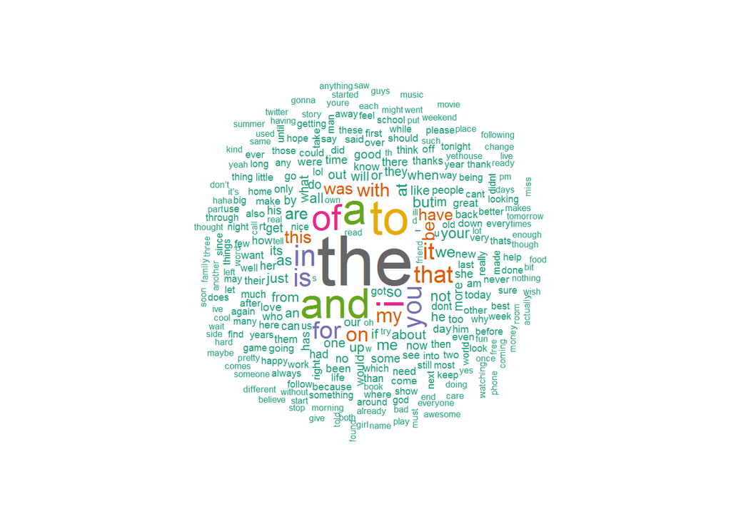

```r
wordcloud(unigram$String, unigram$Count, random.order=FALSE,
          min.freq= 50,
          colors=brewer.pal(8, "Dark2"))
```

# Assess the most frequent words in the sample corpus

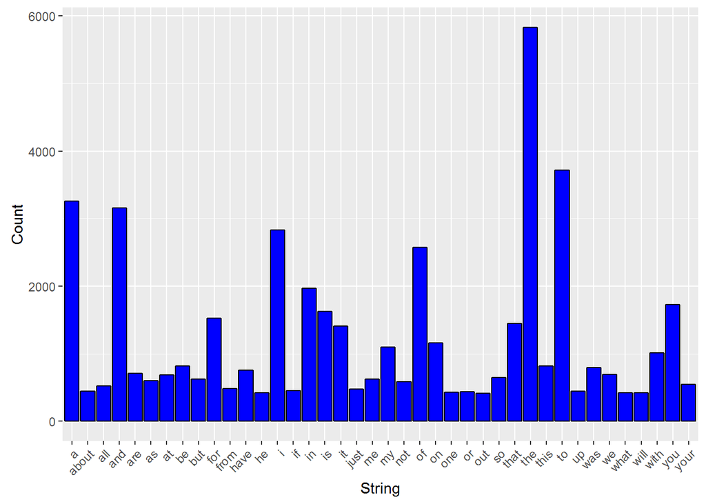

```r
plot1 <- ggplot(unigram[1:40,], aes(String, Count))
plot1 <- plot1 + geom_bar(stat="identity",fill = "blue", color="black")
plot1 <- plot1 + theme(axis.text.x=element_text(angle=45, hjust=1))
plot1
```

# Plot the most common two-word phrases

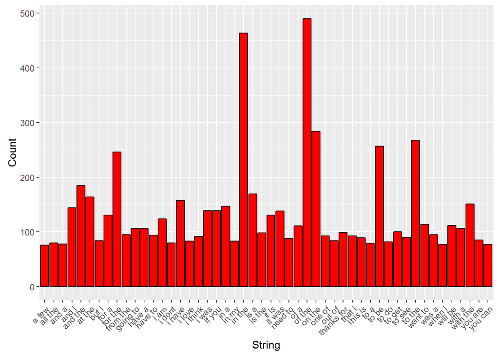

```r
plot2 <- ggplot(bigram[1:50,], aes(String, Count))
plot2 <- plot2 + geom_bar(stat="identity",fill = "red",color="black")
plot2 <- plot2 + theme(axis.text.x=element_text(angle=45, hjust=1))
plot2
```

# Plot the most common three-word phrases

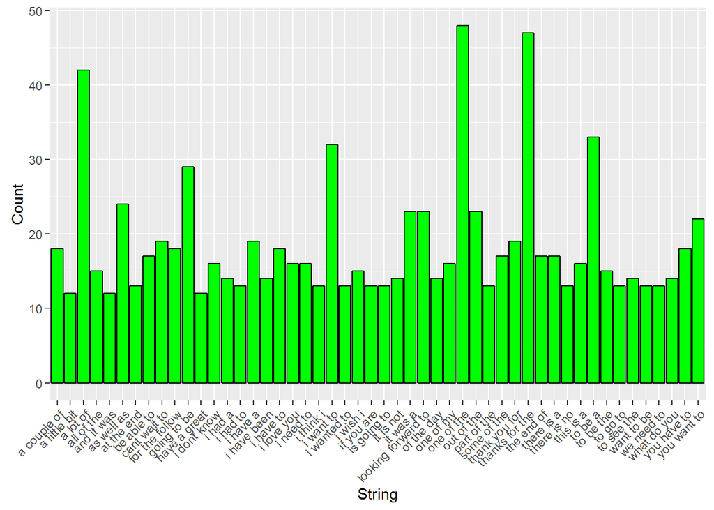

```r
plot3 <- ggplot(trigram[1:50,], aes(String, Count))
plot3 <- plot3 + geom_bar(stat="identity",fill = "green",color="black")
plot3 <- plot3 + theme(axis.text.x=element_text(angle=45, hjust=1))
plot3
```

# Plot the most common four-word phrases

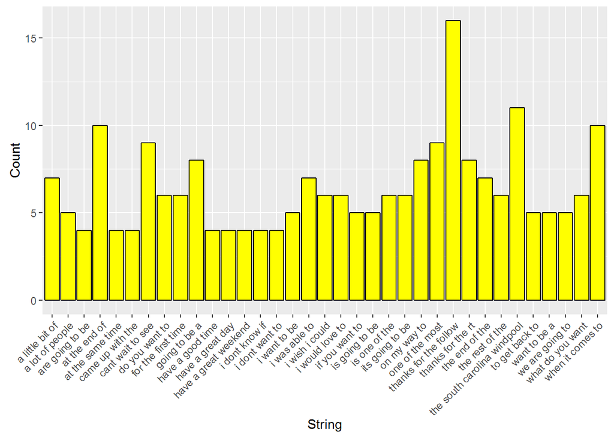

```r
plot4 <- ggplot(fourgram[1:35,], aes(String, Count))
plot4 <- plot4 + geom_bar(stat="identity", fill = "yellow", color="black")
plot4 <- plot4 + theme(axis.text.x=element_text(angle=45, hjust=1))
plot4
```

# Plot the frequent five-word phrases

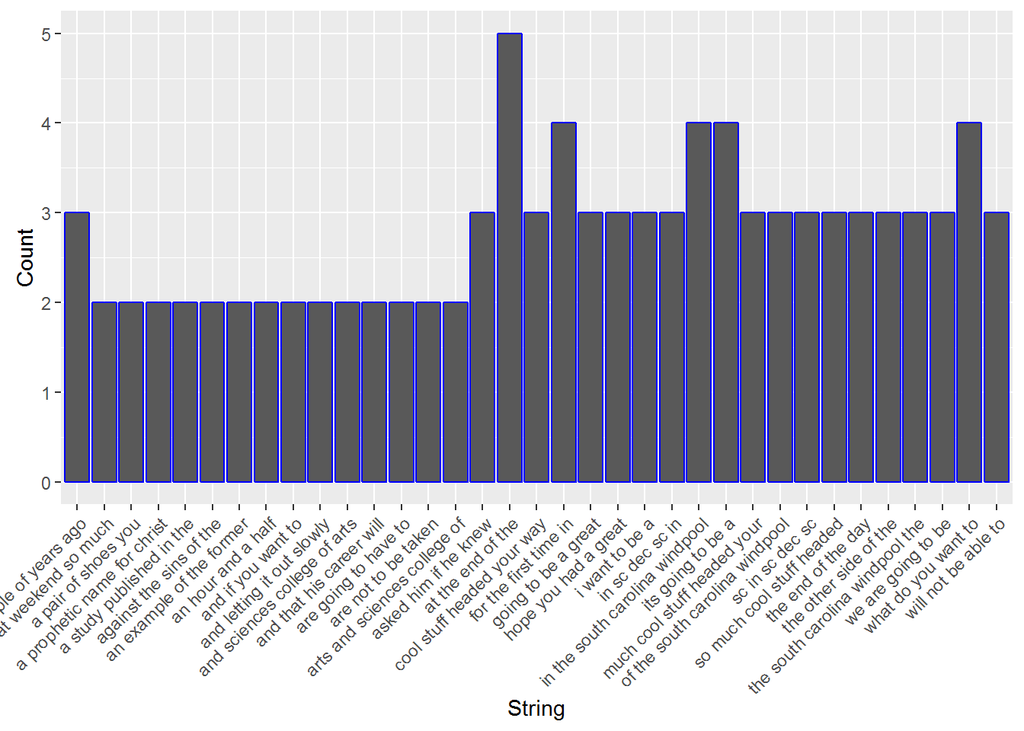

```r
plot5 <- ggplot(fivegram[1:35,], aes(String, Count))
plot5 <- plot5 + geom_bar(stat="identity", color = "blue")
plot5 <- plot5 + theme(axis.text.x=element_text(angle=45, hjust=1))
plot5
```

# Plot the frequent six-word phrases

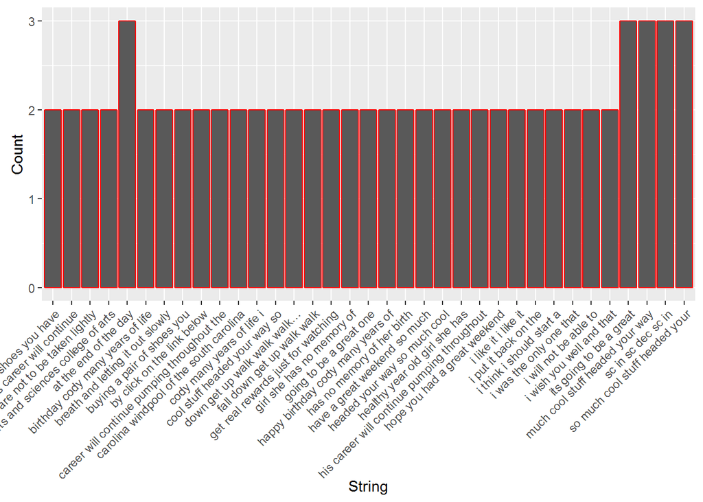

```r
plot6 <- ggplot(sixgram[1:35,], aes(String, Count))
plot6 <- plot6 + geom_bar(stat="identity", color = "red")
plot6 <- plot6 + theme(axis.text.x=element_text(angle=45, hjust=1))
plot6
```

# Plot the frequent seven-word phrases

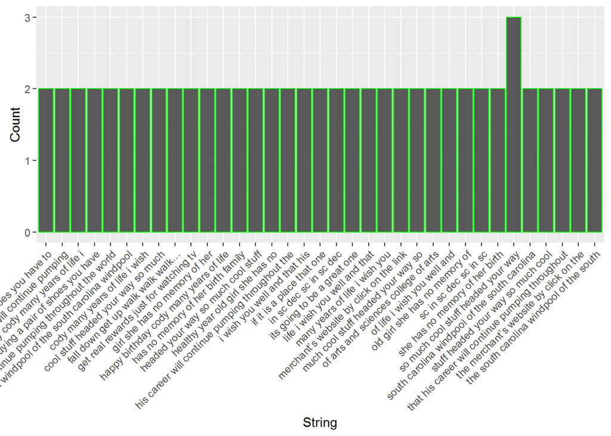

```r
plot7 <- ggplot(sevengram[1:35,], aes(String, Count))
plot7 <- plot7 + geom_bar(stat="identity", color = "green")
plot7 <- plot7 + theme(axis.text.x=element_text(angle=45, hjust=1))
plot7
```

## Task 5: Detecting foreign languages in the data

```r
require(devtools)
library(slam)
library(textcat)
table(textcat(CorpusClean))
```

```
##
##           afrikaans            albanian             bosnian
##                  79                   1                   2
##              breton             catalan      croatian-ascii
##                  18                  19                   9
##     czech-iso8859_2              danish               dutch
##                  19                  39                  22
##             english           esperanto            estonian
##                4685                   1                   8
##             finnish              french             frisian
##                   1                  28                  66
##              german           hungarian           icelandic
##                   9                   4                   2
##          indonesian               irish             italian
##                   8                   9                  20
##               latin             latvian          lithuanian
##                  28                   3                   4
##               malay                manx      middle_frisian
##                   7                  59                  62
##           norwegian              polish          portuguese
##                  10                   7                   6
##            romanian           rumantsch            sanskrit
##                  33                  32                   1
##               scots       serbian-ascii        slovak-ascii
##                1251                   5                  16
##  slovak-windows1250     slovenian-ascii slovenian-iso8859_2
##                   2                   7                   6
##             spanish             swahili             swedish
##                  16                   3                  28
##             tagalog             turkish               welsh
##                  17                   5                  12
```

## Findings and next steps

Explore more efficient analytic functions that do not consume high processing resources

Apparently with the some of the text contains foreign language (other than English) words.

Possibly refine the corpus even more

The n-gram modelling seems like a plausible strategy to base the text predictive model.Need to refine n-gram results for example sort by most frequent word phrases.

Next steps is to refine sampling and develop the the basic text predictive model based on the n-grams and progressively improve it.